# Exercise I: Frequency-based methods

## Variability statistics

Aim: locate the *LCT* selection signal using genotype data

We will use `selscan` to calculate nucleotide diversity from a prepared VCF. Let's start by setting the paths to the data and program:

```
## path for this exercise
ThePath=/course/popgen24/cindy/selectionExercises

#selscan program folder
SS=/course/popgen24/cindy/selectionExercises/prog/selscan-linux-1.3.0/

# CEU VCF for the regional diversity analysis
ceuVCF=$ThePath/ceuLCT.recode.vcf
```

Let's inspect one VCF record and identify how the diploid genotypes are represented:

```
tail -n 1 $ThePath/ceuLCT.recode.vcf
```

```
2	139999942	.	A	G	100	PASS	.	GT	0|0	0|0	0|0	0|0	0|0	0|0	0|0	0|0	0|0	0|0	0|0	0|1	0|0	0|0	0|0	0|0	0|0	0|0	0|0	0|0	0|0	0|0	0|0	0|0	0|0	0|0	0|0	0|0	0|0	0|0	0|0	0|0	0|0	0|0	0|0	0|0	0|0	0|0	0|0	0|0	0|0
```

Each diploid genotype contains two alleles: `0` denotes the reference allele and `1` the alternate allele. A vertical pipe (`|`) indicates that the genotype is phased, whereas a slash (`/`) indicates unknown phase. The diversity calculation below uses allele counts and does not require phase information.

### Tajima's Theta (Tajima's π or nucleotide diversity)

First lets look at the variability of the data in the CEU.

- If there has been positive selection at the LCT loci what do you expect?

With that in mind then try to estimate Tajima's theta (pi) in 10k windows using selscan using the following command:

```
$SS/selscan --pi --vcf $ceuVCF --pmap --out ceuLCT --threads 8 --pi-win 10000
```

```
selscan v1.3.0
Opening /course/popgen24/cindy/selectionExercises/ceuLCT.recode.vcf...
Loading 82 haplotypes and 150341 loci...
Opening /course/popgen24/cindy/selectionExercises/ceuLCT.recode.vcf...
Loading map data for 150341 loci
Starting pi calculations with 10000bp windows.

Finished.
```

Let's try to have look at the last 10 lines of the output file (which are named after the window size):

```
tail -n 10 ceuLCT.pi.10000bp.out
```

```
139900001 139910000 6.21198
139910001 139920000 7.70581
139920001 139930000 4.25173
139930001 139940000 16.3996
139940001 139950000 15.1126
139950001 139960000 11.4983
139960001 139970000 11.1105
139970001 139980000 8.60464
139980001 139990000 8.17435
139990001 140000000 9.36917
```

- What is being output here?

Now try to plot the results in R using e.g. the following command:

```
r<-read.table("ceuLCT.pi.10000bp.out",head=F)
r<-subset(r,V3!=0)
plot(r[,1]/1e6,r[,3],ylab="pi",xlab="Position (Mb)",pch=20)
causalSNP <- 136608646/1e6
abline(v=causalSNP,col="red")
legend("topleft",lty=1,col="red","LCT")
```

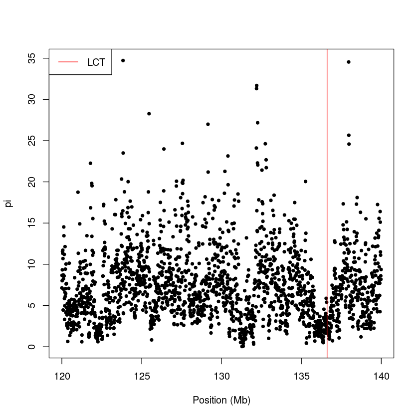

- Does the LCT have visibly reduced variability? Why?

To determine whether it is extreme we can compare with the pi values in rest of the region using the following R code:

```
#continue in R

hist(r[,3],br=100, main="Histogram of pi values for all windows", xlab="pi")
causalWin<-subset(r,V1<(causalSNP*1e6)& V2>(causalSNP*1e6))
abline(v=causalWin[,3],col="red")
legend("topright",lty=1,col="red","LCT")
print(paste("The pi value in the window with LCT is",causalWin[,3]))
```

```
[1] "The pi value in the window with LCT is 2.41313"
```

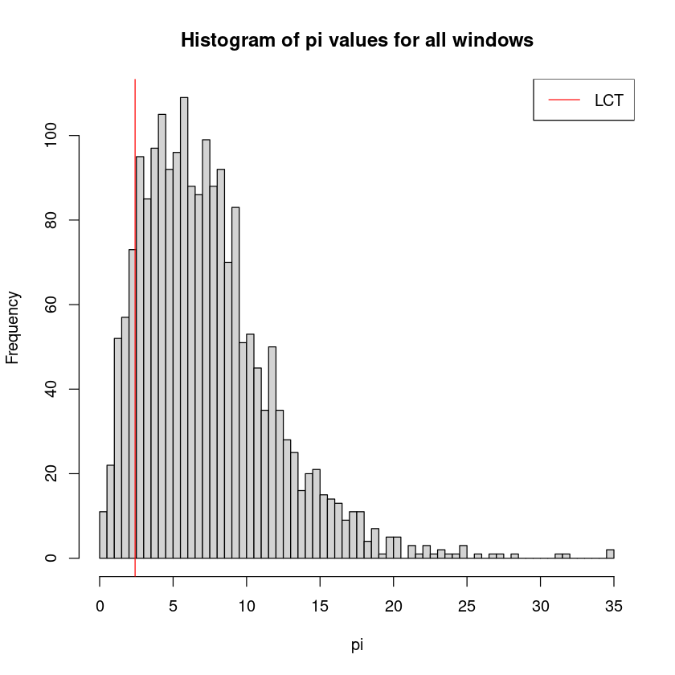

- Is the variability in the *LCT* region extreme?

### How much does the window size matter?

The original analysis used **10 kb windows**. We will now compare it with two alternative choices:

- **1 kb windows**
- **1 Mb windows**

Before running the cells, predict how changing the window size might affect the result. Then run both cells below; the commands use different output names, so they will not overwrite the original 10 kb result.

```
# Alternative window sizes for comparison with the original 10 kb analysis.
# Notice the TWO things changed in each command: --pi-win and --out.

# 1 kb windows
$SS/selscan --pi --vcf $ceuVCF --pmap \
  --out ceuLCT_1kb --threads 8 --pi-win 1000

# 1 Mb windows
$SS/selscan --pi --vcf $ceuVCF --pmap \
  --out ceuLCT_1Mb --threads 8 --pi-win 1000000
```

```
selscan v1.3.0
Opening /course/popgen24/cindy/selectionExercises/ceuLCT.recode.vcf...
Loading 82 haplotypes and 150341 loci...
Opening /course/popgen24/cindy/selectionExercises/ceuLCT.recode.vcf...
Loading map data for 150341 loci
Starting pi calculations with 1000bp windows.

Finished.
selscan v1.3.0
Opening /course/popgen24/cindy/selectionExercises/ceuLCT.recode.vcf...
Loading 82 haplotypes and 150341 loci...
Opening /course/popgen24/cindy/selectionExercises/ceuLCT.recode.vcf...
Loading map data for 150341 loci
Starting pi calculations with 1000000bp windows.

Finished.
```

The output filename contains the window size. The next cell reads the new **1 kb** and **1 Mb** files as well as the original **10 kb** file. Because this version of `selscan` reports diversity summed across each window, the code divides by the window width before comparing them. This gives π per base pair and puts all three plots on the same scale.

```
# The filenames must match the --out and --pi-win values used above.
pi_1kb_raw  <- read.table("ceuLCT_1kb.pi.1000bp.out", header=FALSE)
pi_10kb_raw <- read.table("ceuLCT.pi.10000bp.out", header=FALSE)
pi_1Mb_raw  <- read.table("ceuLCT_1Mb.pi.1000000bp.out", header=FALSE)

# Keep only the 20 Mb interval covered by this VCF. selscan also writes empty
# windows between position 1 and the beginning of the data interval.
keep_LCT_interval <- function(x) subset(x, V2 > 120e6 & V1 <= 140e6)
pi_1kb_raw  <- keep_LCT_interval(pi_1kb_raw)
pi_10kb_raw <- keep_LCT_interval(pi_10kb_raw)
pi_1Mb_raw  <- keep_LCT_interval(pi_1Mb_raw)

# First count windows for which selscan returned zero inside the data interval.
window_summary <- data.frame(
  window_size = c("1 kb", "10 kb", "1 Mb"),
  total_windows = c(nrow(pi_1kb_raw), nrow(pi_10kb_raw), nrow(pi_1Mb_raw)),
  zero_windows = c(sum(pi_1kb_raw$V3 == 0),
                   sum(pi_10kb_raw$V3 == 0),
                   sum(pi_1Mb_raw$V3 == 0))
)
window_summary$percent_zero <- round(100 * window_summary$zero_windows /
                                     window_summary$total_windows, 1)
window_summary

# As above, omit zero-valued windows from the plots.
pi_1kb  <- subset(pi_1kb_raw, V3 != 0)
pi_10kb <- subset(pi_10kb_raw, V3 != 0)
pi_1Mb  <- subset(pi_1Mb_raw, V3 != 0)

# selscan reports the diversity summed within a window. Divide by window
# width so that the three window sizes can be compared fairly.
pi_1kb$pi_per_bp  <- pi_1kb$V3 / 1000
pi_10kb$pi_per_bp <- pi_10kb$V3 / 10000
pi_1Mb$pi_per_bp  <- pi_1Mb$V3 / 1000000

causalSNP_mb <- 136608646 / 1e6
y_limits <- range(c(pi_1kb$pi_per_bp, pi_10kb$pi_per_bp,
                    pi_1Mb$pi_per_bp), finite=TRUE)
old_par <- par(no.readonly=TRUE)
par(mfrow=c(3, 1), mar=c(4, 4, 2, 1))

plot(pi_1kb$V1 / 1e6, pi_1kb$pi_per_bp, ylim=y_limits, pch=20, cex=0.35,
     xlab="Position (Mb)", ylab="pi per bp",
     main="1 kb windows")
abline(v=causalSNP_mb, col="red")

plot(pi_10kb$V1 / 1e6, pi_10kb$pi_per_bp, ylim=y_limits, pch=20, cex=0.55,
     xlab="Position (Mb)", ylab="pi per bp",
     main="10 kb windows: original analysis")
abline(v=causalSNP_mb, col="red")

plot(pi_1Mb$V1 / 1e6, pi_1Mb$pi_per_bp, ylim=y_limits, pch=20,
     xlab="Position (Mb)", ylab="pi per bp",
     main="1 Mb windows")
abline(v=causalSNP_mb, col="red")

par(old_par)
```

A data.frame: 3 × 4

| window_size <chr> | total_windows <int> | zero_windows <int> | percent_zero <dbl> |
| --- | --- | --- | --- |
| 1 kb | 20000 | 1518 | 7.6 |
| 10 kb | 2000 | 3 | 0.1 |
| 1 Mb | 20 | 0 | 0.0 |

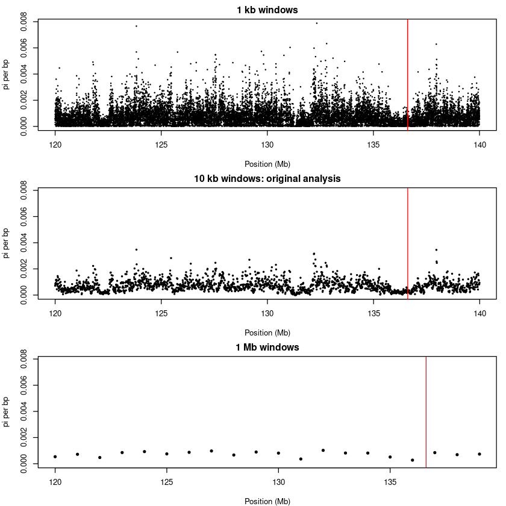

Discuss the comparison:

- Which window size gives the noisiest result or the most zero-valued windows?
- Which window size loses the most spatial detail around *LCT*?
- Which of the three sizes gives the most useful balance between noise and resolution?
- Why might a very broad window dilute a local signal of selection?

## Population genetic differentiation statistics

### $F_{ST}$ and Population Branch Statistics (PBS)

Now that we've tried out single-population statistics, lets see how a selection scan that compares two populations performs.

The data for Hudson's $F_{ST}$ comparing CEU (Europeans) and YRI (West Africans) for the *LCT* region has already been pre-ran using 10000bp window sizes.

Let's copy the data into your folder and plot the results in `R`:

```
r <- read.table("/course/popgen24/cindy/selectionExercises/run/comboLCT.fst.out",header=T)
causalSNP <- 136608646
#plot FST results
plot(r$POS,r$FST,ylab="Fst");
abline(v=causalSNP,col="red")
```

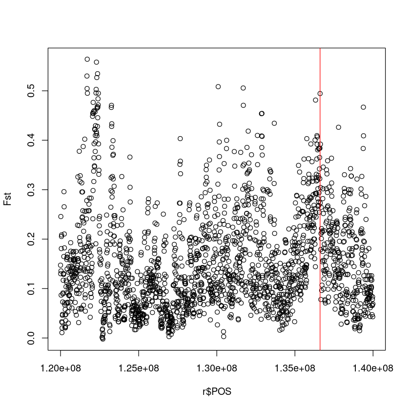

Similarly, data for PBS comparing CEU and CHB (Han Chinese) to YRI for the *LCT* region has been performed with window sizes consisting of 75 variants per window (approximately 10000 bp).

Let's plot the pre-ran PBS results in `R`:

```
r <- read.table("/course/popgen24/cindy/selectionExercises/run/comboLCT.pbs.out",header=T)
causalSNP <- 136608646
#plot PBS results
plot(r$POS,r$PBS,ylab="PBS");
abline(v=causalSNP,col="red")
```

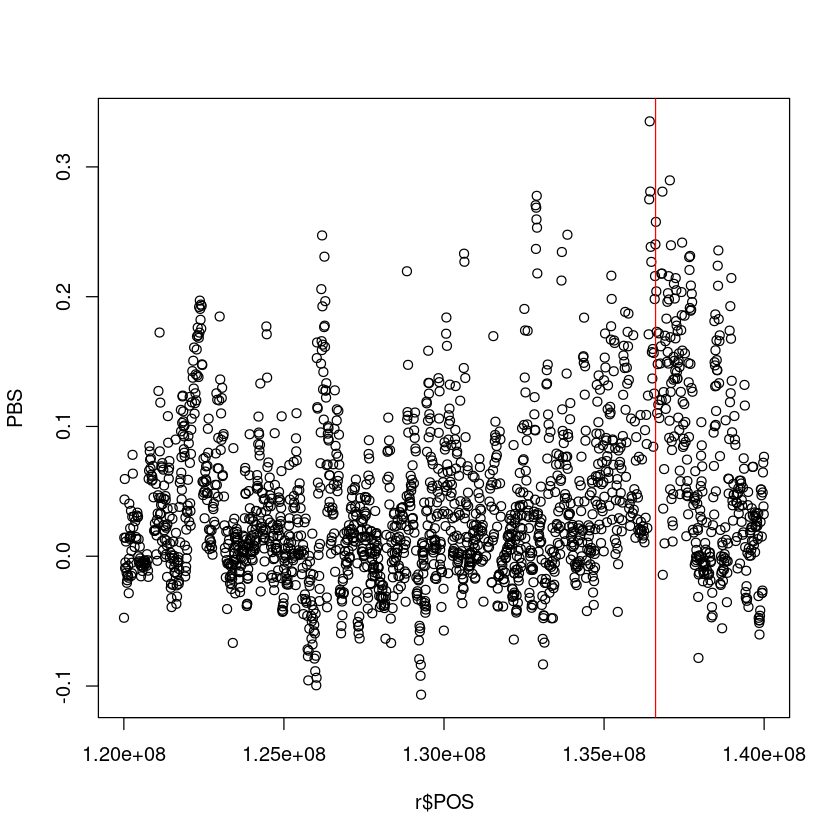

**- How do both of these selection methods (Fst and PBS) compare to Tajima's π?**

### Quick check: frequency-based selection statistics

Run the following cell for a short quiz before moving from the regional examples to a whole-genome PBS scan.

```
from jupyterquiz import display_quiz

display_quiz('/davidData/users/thomas/workshop/selection_scans_quizzes/human_frequency_methods.json')
```

# Exercise II: Whole-genome PBS with 1000 Genomes

Let's explore the human genome using PBS. First copy the precomputed allele-frequency information from the 1000 Genomes Project.

```
cp -r -sf  /course/popgen24/anders/selectionScan/ ~/
#enter the folder you just copied
cd ~/selectionScan
```

Load the data and plotting functions into R. You do not need to understand all of this setup code.

```
## load data and function
setwd("~/selectionScan/")

source("server.R")
winSize <- 50000
shinyDir<- "~/selectionScan/tmp/"

shinyPBS<-paste0(shinyDir,"pbs")
shinyCSV<-paste0(shinyDir,"pbs.csv")
```

First select three populations:

```
NAT - Native Americans (PERU+Mexico)
CHB – East Asian - Han Chinese
CEU – Central Europeans
YRI – African - Nigerians
```

The first population defines the branch being investigated; the other two provide the comparisons. Choose CEU first, followed by CHB and YRI.

```
#"NAT", "CEU", "CHB","YRI"

#### choose populations
#pops 1=NAT,2=CHB",3=CEU",4=YRI
myPops <- c(3,2,4)
```

First, get an overview of PBS across the whole genome with a Manhattan plot.

```
options(repr.plot.width=17, repr.plot.height=8)
#### choose populations
PBSmanPlot(myPops)
```

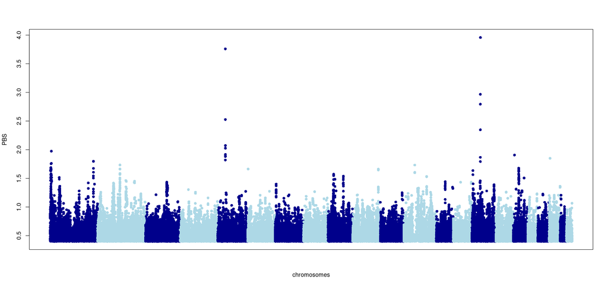

Note which chromosomes have extreme values. A high PBS value means a long estimated branch length for a given population. We can then inspect one chromosome in more detail.

Choose the chromosome with the highest PBS value and set the starting position to `-1` to display the whole chromosome.

e.g.

# see entire chromosome 1

```
options(repr.plot.width=17, repr.plot.height=10)
#modify below code with your selected chromsome
PBSmanRegion(myPops,chrom=1,start=-1)
```

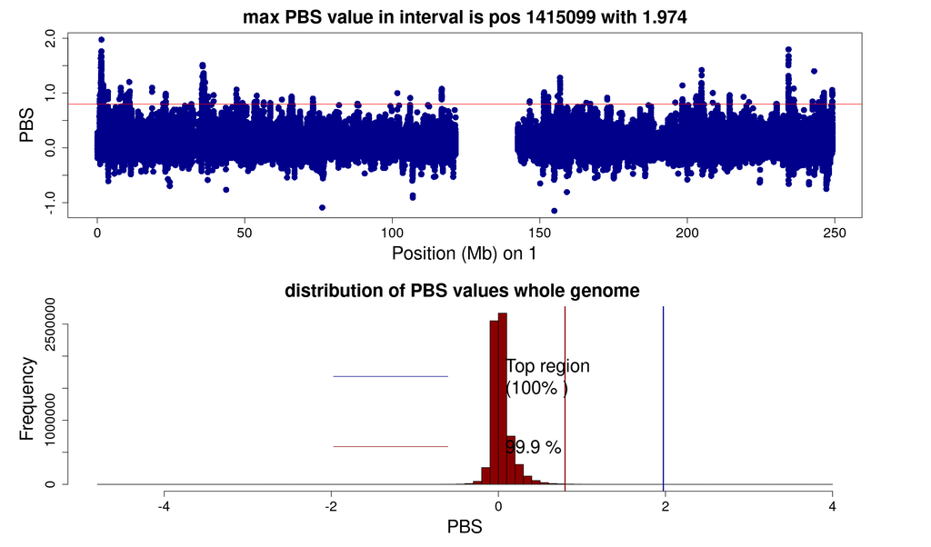

Zoom in to the peak by changing start and end position in the code above.